# Project 4 ALS R1R2

HANG HU hh2718

11/20/2019

### Step 1 Load Data and Train-test Split

```r
library(dplyr)
```

```r
library(tidyr)
library(ggplot2)
data <- read.csv("C:/Users/huhan/OneDrive/Desktop/2019 Fall/GR 5243/fall2019-project4-sec2-grp2-master/fall2019-project4-sec2-grp2-master/data/ml-latest-small/ratings.csv")
set.seed(0)
## shuffle the row of the entire dataset
data <- data[sample(nrow(data)),]
## get a small dataset that contains all users and all movies
unique.user<-duplicated(data[,1])
unique.movie<-duplicated(data[,2])
index<-unique.user & unique.movie
all.user.movie <- data[!index,]

## split training and test on the rest
rest <- data[index,]
test_idx <- sample(rownames(rest), round(nrow(data)/5, 0))
train_idx <- setdiff(rownames(rest), test_idx)

## combine the training with the previous dataset, which has all users and all movies
data_train <- rbind(all.user.movie, data[train_idx,])
data_test <- data[test_idx,]

## sort the training and testing data by userId then by movieId,
## so when we update p and q, it is less likely to make mistakes
data_train <- arrange(data_train, userId, movieId)
data_test <- arrange(data_test, userId, movieId)
```

- For algorithms, the referenced paper are:

A1. Stochastic Gradient Descent Section: Learning Algorithms-Stochastic Gradient Descent

A2. Gradient Descent with Probabilistic Assumptions Section 2

A3. Alternating Least Squares Section 3.1

- For regularizations, the referenced paper are:

R1. Penalty of Magnitudes Section: a Basic Matrix Factorization Model

R2. Bias and Intercepts Section: Adding Biases

R3. Temporal Dynamics Section 4

```r
U <- length(unique(data$userId))
I <- length(unique(data$movieId))
source("C:/Users/huhan/OneDrive/Desktop/2019 Fall/GR 5243/fall2019-project4-sec2-grp2-master/fall2019-project4-sec2-grp2-master/lib/ALS.R1+R2.R")
```

#### Step 2.2 Parameter Tuning

Here you should tune parameters, such as the dimension of factor and the penalty parameter $\lambda$ by cross-validation.

```r
source("C:/Users/huhan/OneDrive/Desktop/2019 Fall/GR 5243/fall2019-project4-sec2-grp2-master/fall2019-project4-sec2-grp2-master/lib/cross_validation_R1R2.R")
f_list <- seq(10, 20, 10)
l_list <- seq(1, 2, 1)
f_l <- expand.grid(f_list, l_list)
```

#### It takes time for running again and result has been saved.

```r
result_summary <- array(NA, dim = c(nrow(f_l), 10, 4))
run_time <- system.time(for(i in 1:nrow(f_l)){
    par <- paste("f = ", f_l[i,1], ", lambda = ", 10*f_l[i,2])
    cat(par, "\n")
    current_result <- cv.function(data, K = 5, f = f_l[i,1], lambda = 10*f_l[i,2])
    result_summary[,,i] <- matrix(unlist(current_result), ncol = 10, byrow = T)
    print(result_summary)

})

save(result_summary, file = "C:/Users/huhan/OneDrive/Desktop/2019 Fall/GR 5243/fall2019-project4-sec2-grp2-master/fall2019-project4-sec2-grp2-master/output/rmser1r2new.Rdata")
```

[figure not shown]

```r
load("C:/Users/huhan/OneDrive/Desktop/2019 Fall/GR 5243/fall2019-project4-sec2-grp2-master/fall2019-project4-sec2-grp2-master/output/rmser1r2new.Rdata")
rmse <- data.frame(rbind(t(result_summary[1,,]), t(result_summary[2,,])), train_test = rep(c("Train", "Test"), each = 4), par = rep(paste("f = ", f_l[,1], ", lambda = ", 10^f_l[,2]), times = 2)) %>% gather("epoch", "RMSE", -train_test, -par)
rmse$epoch <- as.numeric(gsub("X", "", rmse$epoch))
rmse %>% ggplot(aes(x = epoch, y = RMSE, col = train_test)) + geom_point() + facet_grid(~par)
```

### Step 3 Postprocessing

After matrix factorization, postporcessing will be performed to improve accuracy. The referenced papers are:

P1:Global bias correction Section 4.1

P2:Postprocessing SVD with KNN Section 3.5

P3:Postprocessing SVD with kernel ridge regression Section 3.6

P4:Linearly combination of predictors Section 4.1

```r
result <- ALS.R1R2(f = 20, lambda =10,
                    max.iter = 4, data = data, train = data_train, test = data_test)

save(result, file = "C:/Users/huhan/OneDrive/Desktop/2019 Fall/GR 5243/fall2019-project4-sec2-grp2-master/fall2019-project4-sec2-grp2-master/output/mat_fac_r1r2new.RData")
```

#### Knn PostProcessing

```r
load("C:/Users/huhan/OneDrive/Desktop/2019 Fall/GR 5243/fall2019-project4-sec2-grp2-master/fall2019-project4-sec2-grp2-master/output/mat_fac_r1r2new.RData")
library(lsa)
library(plyr)
ratingmean<-function(data){
  mean(data$rating)
}

rating<-ddply(data,.(movieId),ratingmean)
rating$index<-c(1:nrow(rating))


l_distance<-cosine(result$q)
diag(l_distance)<-0
cos_id<-rep(1:I,ncol=I)
knn_r<-rep(1:I,ncol=I)
for (i in 1:I){
    cos_id[i]<-which.max(rank(l_distance[,i]))
    knn_r[i]<-rating[rating$index==cos_id[i],]$V1
  }
```

#### Linear Regression for Training dataset

```r
data_train$movieindex<-dense_rank(data_train$movieId)

r<-rep(0,nrow(data_train))
for (i in 1:nrow(data_train)){
  rowindex<-data_train$userId[i]
  columindex<-data_train$movieindex[i]
  qi <- as.matrix(result$p[,rowindex])
  qj <- as.matrix(result$q[,columindex])
  r[i]<-t(qi)%*%qj
  }
```

```r
v<-rep(0,nrow(data_train))
for (i in 1:nrow(data_train)){
  rowindex<-data_train$userId[i]
  columindex<-data_train$movieindex[i]
  qi <- as.matrix(result$bu[rowindex])
  qj <- as.matrix(result$bi[columindex])
  v[i]<-qi+qj+result$mu
}

w<-knn_r[data_train$movieindex]
```

```r
data_train_linear<-as.data.frame(cbind(data_train$rating,r,v,w))
fit<-lm(V1~r+v+w,data=data_train_linear)
exp_rating<-predict(fit,data_train_linear)
(rmse_adj <- sqrt(mean((data_train_linear$V1 - exp_rating)^2)))
```

```
## [1] 0.5925521
```

```r
cat("The RMSE train of the adjusted model is", rmse_adj)
```

```
## The RMSE train of the adjusted model is 0.5925521
```

#### prediction

```r
data_test$movieindex<-dense_rank(data_test$movieId)

r1<-rep(0,nrow(data_test))
for (i in 1:nrow(data_test)){
  rowindex<-data_test$userId[i]
  columindex<-data_test$movieindex[i]
  qi <- as.matrix(result$p[,rowindex])
  qj <- as.matrix(result$q[,columindex])
  r1[i]<-t(qi)%*%qj
  }
```

```r
v1<-rep(0,nrow(data_test))
for (i in 1:nrow(data_test)){
  rowindex<-data_test$userId[i]
  columindex<-data_test$movieindex[i]
  qi <- as.matrix(result$bu[rowindex])
  qj <- as.matrix(result$bi[columindex])
  v1[i]<-qi+qj+result$mu
}

w1<-knn_r[data_test$movieindex]
```

```r
data_test_linear<-as.data.frame(cbind(data_test$rating,r1,v1,w1))
exp_rating_test<-predict(fit,data_test_linear)
rmse_adj_test <- sqrt(mean((data_test_linear$V1 - exp_rating_test)^2))
cat("The RMSE test of the adjusted model is", rmse_adj_test)
```

```
## The RMSE test of the adjusted model is 1.342585
```

### Step 4 Evaluation

You should visualize training and testing RMSE by different dimension of factors and epochs ([One Epoch is when an ENTIRE dataset is passed forward and backward through the neural network only ONCE](https://towardsdatascience.com/epoch-vs-iterations-vs-batch-size-4dfb9c7ce9c9)).

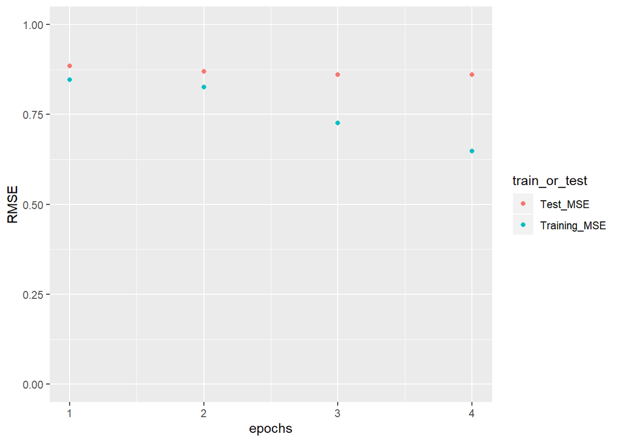

```r
library(ggplot2)

RMSE <- data.frame(epochs = seq(1, 4, 1), Training_MSE = result$train_RMSE, Test_MSE = result$test_RMSE) %>% gather(key = train_or_test, value = RMSE, -epochs)

RMSE %>% ggplot(aes(x = epochs, y = RMSE,col = train_or_test)) + geom_point() + scale_x_discrete(limits = seq(1, 5, 1)) + xlim(c(1, 4))+ylim(c(0,1))
```